# Natural Language Processing - A classification of SMS as Ham and Spam using Naive Bayes Algorithm

Dayo John

22 April 2018

## Naive Bayes (Part 1)

The part 1 of this project will focus on the classification of SMS messages to `HAM` and `SPAM`. The `HAM` is for the good SMS while the `SPAM` is for the bad one. The primary focus is to use the Naive Bayes classifier and train our model using the Laplace Estimator.

The following steps will be taken:

1. Getting Dataset
2. Loading Dataset
3. Data Exploration and Observation
4. Data Cleansing and Standardization
5. Word Cloud (Optional)
6. Creating DTM Sparse Matrix
7. Creating Training and Test Data
8. Reducing the Word Frequency
9. Observe the Process (so far)
10. Apply the Naive Bayes Algorithm for Model
11. Improving Model
12. Remark

### 1. Getting Dataset

The dataset was downloaded to a desire folder from the link - [SMS Spam Collection v. 1](http://www.dt.fee.unicamp.br/~tiago/smsspamcollection/smsspamcollection.zip).

### 2. Loading Dataset

```r
ham_spam_SMS_messages <- read.table(file.choose(), sep = "\t", stringsAsFactors = F, quote = "")
```

```r
head(ham_spam_SMS_messages)
```

```
##     V1
## 1  ham
## 2  ham
## 3 spam
## 4  ham
## 5  ham
## 6 spam
##                                                                                                                                                            V2
## 1                                             Go until jurong point, crazy.. Available only in bugis n great world la e buffet... Cine there got amore wat...
## 2                                                                                                                               Ok lar... Joking wif u oni...
## 3 Free entry in 2 a wkly comp to win FA Cup final tkts 21st May 2005. Text FA to 87121 to receive entry question(std txt rate)T&C's apply 08452810075over18's
## 4                                                                                                           U dun say so early hor... U c already then say...
## 5                                                                                               Nah I don't think he goes to usf, he lives around here though
## 6        FreeMsg Hey there darling it's been 3 week's now and no word back! I'd like some fun you up for it still? Tb ok! XxX std chgs to send, Â£1.50 to rcv
```

```r
names(ham_spam_SMS_messages) <- c("Type", "Text")
```

```r
head(ham_spam_SMS_messages)
```

```
##   Type
## 1  ham
## 2  ham
## 3 spam
## 4  ham
## 5  ham
## 6 spam
##                                                                                                                                                          Text
## 1                                             Go until jurong point, crazy.. Available only in bugis n great world la e buffet... Cine there got amore wat...
## 2                                                                                                                               Ok lar... Joking wif u oni...
## 3 Free entry in 2 a wkly comp to win FA Cup final tkts 21st May 2005. Text FA to 87121 to receive entry question(std txt rate)T&C's apply 08452810075over18's
## 4                                                                                                           U dun say so early hor... U c already then say...
## 5                                                                                               Nah I don't think he goes to usf, he lives around here though
## 6        FreeMsg Hey there darling it's been 3 week's now and no word back! I'd like some fun you up for it still? Tb ok! XxX std chgs to send, Â£1.50 to rcv
```

### 3. Data Exploration and Observation

In this section, the data exploration was to inspect the structure of the datasetby using the `str` function.

```r
str(ham_spam_SMS_messages)
```

```
## 'data.frame':    5574 obs. of  2 variables:
##  $ Type: chr  "ham" "ham" "spam" "ham" ...
##  $ Text: chr  "Go until jurong point, crazy.. Available only in bugis n great world la e buffet... Cine there got amore wat..." "Ok lar... Joking wif u oni..." "Free entry in 2 a wkly comp to win FA Cup final tkts 21st May 2005. Text FA to 87121 to receive entry question("| __truncated__ "U dun s…
```

```r
ham_spam_SMS_messages$Type <- factor(ham_spam_SMS_messages$Type)
```

Then, view the result of the converted field as follows:

```r
str(ham_spam_SMS_messages$Type)
```

```
##  Factor w/ 2 levels "ham","spam": 1 1 2 1 1 2 1 1 2 2 ...
```

Afterwards, check the count for the unique factors.

```r
table(ham_spam_SMS_messages$Type)
```

```
##
##  ham spam
## 4827  747
```

### 4. Data Cleansing and Standardization

To do the data cleaning and standardization, important that the following are done using the `tm_map()` function:

- Install packages where necessary - `tm` and `slam`
- Create a Volatile Corpus `(VCorpus)` for the data
- `tolower()`: Make all characters lowercase
- `removePunctuation()`: Remove all punctuation marks
- `removeNumbers()`: Remove numbers
- `stripWhitespace()`: Remove excess whitespace
- `stopwords()`: Remove stopwords/filler words such as to, and, but *et cetera*
- `stemDocument()` for whole document and `wordStem()` for single words

```r
library(tm)
```

**NOTE:**

1. The “Corpus” is a collection of text documents.
2. There are two types of `CORPUS` data type, the Permanent Corpus, `PCorpus` and the Volatile Corpus, `VCorpus`. The difference between the two corpuses is in the way they are stored (on the computer).
3. For this task, a `VCorpus` is used because it is held in the computer’s Random Access Memory (would be destroyed when the R object containing it is destroyed) while `PCorpus` is stored on the disk (stores outside the memory, *for example in a Database*). So for memory efficiency, the `VCorpus` is preferred.
4. The `VCorpus` is part of the `tm` used for natural language processing (NLP). It is needed to convert to Corpus.
5. Also, to be noted, is that `tolower` is part of base R, while the other `cleansing` functions are part of `tm` package.

```r
ham_spam_SMS_messages_corpus <- VCorpus(VectorSource(ham_spam_SMS_messages$Text))
```

By trying to view the `VCorpus` result, the following is seen, which does not give more useful information.

```r
ham_spam_SMS_messages_corpus
```

```
## <<VCorpus>>
## Metadata:  corpus specific: 0, document level (indexed): 0
## Content:  documents: 5574
```

Therefore, to see more useful details, we can inspect the the summary brief of the `VCorpus` by using `inspect` and `as.character`. The traditional `head` will not yield desired output as it only display as `Metadata`.

```r
inspect(ham_spam_SMS_messages_corpus[1:3])
```

```
## <<VCorpus>>
## Metadata:  corpus specific: 0, document level (indexed): 0
## Content:  documents: 3
##
## [[1]]
## <<PlainTextDocument>>
## Metadata:  7
## Content:  chars: 111
##
## [[2]]
## <<PlainTextDocument>>
## Metadata:  7
## Content:  chars: 29
##
## [[3]]
## <<PlainTextDocument>>
## Metadata:  7
## Content:  chars: 155
```

```r
as.character(ham_spam_SMS_messages_corpus[[1]])
```

```
## [1] "Go until jurong point, crazy.. Available only in bugis n great world la e buffet... Cine there got amore wat..."
```

Additionally, the `lapply` function can be used with the special function `as.character`, which gives more detail information of the data as shown below:

```r
lapply(ham_spam_SMS_messages_corpus[1:6], as.character)
```

```
## $`1`
## [1] "Go until jurong point, crazy.. Available only in bugis n great world la e buffet... Cine there got amore wat..."
##
## $`2`
## [1] "Ok lar... Joking wif u oni..."
##
## $`3`
## [1] "Free entry in 2 a wkly comp to win FA Cup final tkts 21st May 2005. Text FA to 87121 to receive entry question(std txt rate)T&C's apply 08452810075over18's"
##
## $`4`
## [1] "U dun say so early hor... U c already then say..."
##
## $`5`
## [1] "Nah I don't think he goes to usf, he lives around here though"
##
## $`6`
## [1] "FreeMsg Hey there darling it's been 3 week's now and no word back! I'd like some fun you up for it still? Tb ok! XxX std chgs to send, Â£1.50 to rcv"
```

As part of the process of preparing data, the next things to do are change all the (text) data characters into lowercase; remove all punctuation marks; remove numbers; remove excess whitespace; remove stopwords/filler words; and stem the words accordingly.

- `tolower()`: Make all characters lowercase; this is ideal in Natural Language Processing.

```r
ham_spam_SMS_corpus_clean <- tm_map(ham_spam_SMS_messages_corpus, content_transformer(tolower))
```

- `removePunctuation()`: Remove all punctuation marks.

```r
ham_spam_SMS_corpus_clean <- tm_map(ham_spam_SMS_corpus_clean, removePunctuation)
```

- `removeNumbers()`: Remove numbers

```r
ham_spam_SMS_corpus_clean <- tm_map(ham_spam_SMS_corpus_clean, removeNumbers)
```

- `stripWhitespace()`: Remove excess whitespace. For this, the `SnowballC` library needs to be loaded (the package shoud be installed should the library be missing)

```r
library(SnowballC)
ham_spam_SMS_corpus_clean <- tm_map(ham_spam_SMS_corpus_clean, stripWhitespace)
```

- `stopwords()`: Remove stopwords/filler words such as to, and, but et cetera.

```r
ham_spam_SMS_corpus_clean <- tm_map(ham_spam_SMS_corpus_clean, removeWords, stopwords()) # stopwords("en")
```

- `stemDocument()` for whole document and `wordStem()` for single words

```r
ham_spam_SMS_corpus_clean <- tm_map(ham_spam_SMS_corpus_clean, stemDocument)
```

### 5. Word Cloud (Optional)

This is an optional task, we can view the `WORD CLOUD` to visual the extent of some words. To do this, the `wordcloud` package needs to be installed; then the `wordcloud` library loaded accordingly.

```r
library(wordcloud)
```

The output of the wordcloud is given below for observation:

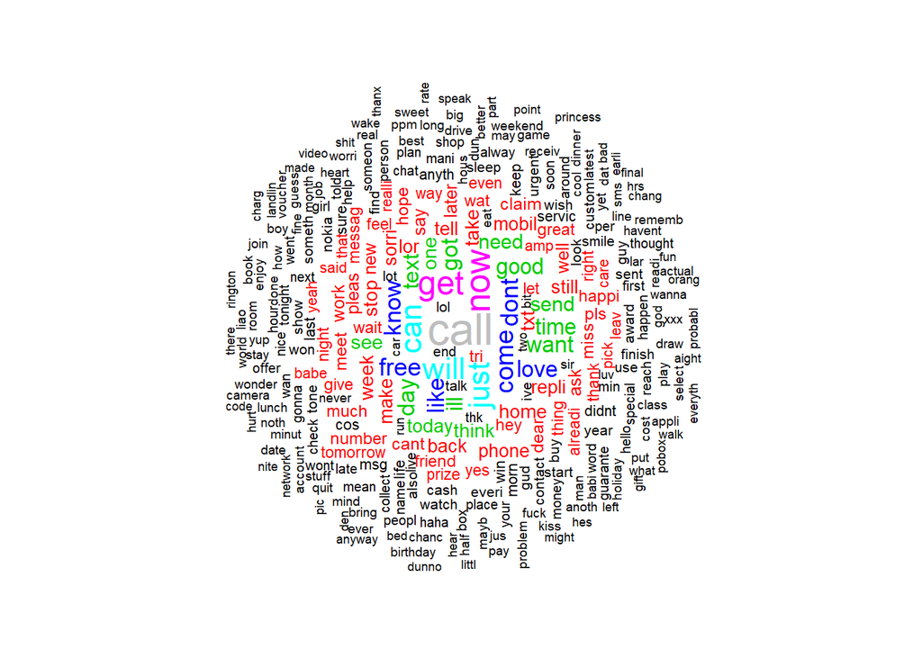

```r
wordcloud(ham_spam_SMS_corpus_clean, scale=c(2,.5), min.freq = 10, max.words = 300,
          random.order = FALSE, rot.per = .5,
          colors= palette())
```

### 6. Creating DTM Sparse Matrix

The Document-Term Matrix (DTM) or Term-Document Matrix (TDM) is a mathematical matrix that describes the frequency of terms that occur basically in documents’ collection. [See more here](https://en.wikipedia.org/wiki/Document-term_matrix). For a DTM, the rows correspond to the documents while the columns correspond to terms in the collection. The TDM is a transpose of the DTM, meaning the rows correspond to terms and the columns are documents. The TDM will be ideal for cases where the number of documents is small while the word list is large. For this task, the DTM is created.

```r
ham_spam_SMS_corpus_dtm <- DocumentTermMatrix(ham_spam_SMS_corpus_clean)
ham_spam_SMS_corpus_dtm
```

```
## <<DocumentTermMatrix (documents: 5574, terms: 6827)>>
## Non-/sparse entries: 42495/38011203
## Sparsity           : 100%
## Maximal term length: 40
## Weighting          : term frequency (tf)
```

To see a more detail DTM output, the special function `as.matrix` was used. The result as shown below, provides insights into the frequency of words in the documents (this view is only for the top 10 rows and first 10 columns).

```r
ham_spam_SMS_corpus_dtmMAtrix <- as.matrix(ham_spam_SMS_corpus_dtm)
ham_spam_SMS_corpus_dtmMAtrix[1:10, 1:10]
```

```
##     Terms
## Docs â‘morrow â‘rent â“harri â£â£ â£award â£call â£ea â£k â£million
##   1         0      0       0    0       0      0    0   0         0
##   2         0      0       0    0       0      0    0   0         0
##   3         0      0       0    0       0      0    0   0         0
##   4         0      0       0    0       0      0    0   0         0
##   5         0      0       0    0       0      0    0   0         0
##   6         0      0       0    0       0      0    0   0         0
##   7         0      0       0    0       0      0    0   0         0
##   8         0      0       0    0       0      0    0   0         0
##   9         0      0       0    0       0      0    0   0         0
##   10        0      0       0    0       0      0    0   0         0
##     Terms
## Docs â£minmobsmorelkpoboxhpfl
##   1                         0
##   2                         0
##   3                         0
##   4                         0
##   5                         0
##   6                         0
##   7                         0
##   8                         0
##   9                         0
##   10                        0
```

### 7. Creating Training and Test Data

To create the Training and Test Data, a split ratio is used with the training set having more. In this task, there are `5574`. A reasonable ratio is `70%:30%`. This gives: `[1:3901, ]` and `[3901:5574, ]`.

```r
ham_spam_SMS_training_set <- ham_spam_SMS_corpus_dtm[1:3901, ]
ham_spam_SMS_test_set <- ham_spam_SMS_corpus_dtm[3901:5574, ]
```

Afterwards, the `Type` labels are created from the raw data to be able to check how the `HAM` and `SPAM` data are distributed; and the `prop.table` is used to see the distribution.

```r
ham_spam_SMS_training_set_Labels <- ham_spam_SMS_messages[1:3901, ]$Type
ham_spam_SMS_test_set_Labels <- ham_spam_SMS_messages[3901:5574, ]$Type
```

```r
prop.table(table(ham_spam_SMS_training_set_Labels))
```

```
## ham_spam_SMS_training_set_Labels
##       ham      spam
## 0.8669572 0.1330428
```

```r
prop.table(table(ham_spam_SMS_test_set_Labels))
```

```
## ham_spam_SMS_test_set_Labels
##       ham      spam
## 0.8637993 0.1362007
```

With the result showing about `87% Ham` and `13% Spam` for Training Set label and about `86% Ham` and `14% Spam` for the Test Set label, it shows the distribution is fairly even and we have got a dataset to work it.

### 8. Reducing the Word Frequency

At this point, words with significantly low frequencies are trimmed out of the training data to improve performance. In this case, terms (words) appearing less than 10 times are removed.

```r
ham_spam_SMS_freq_words <- findFreqTerms(ham_spam_SMS_training_set, 10)
```

```r
str(ham_spam_SMS_freq_words)
```

```
##  chr [1:609] "â€¦" "abiola" "abl" "abt" "account" "actual" "address" ...
```

The more frequent terms from the training set are then used to get all the rows containing the frequent terms.

```r
ham_spam_SMS_training_set_freq10 <- ham_spam_SMS_training_set[, ham_spam_SMS_freq_words]
ham_spam_SMS_test_set_freq10 <- ham_spam_SMS_test_set[, ham_spam_SMS_freq_words]
```

View the sample output as shown below:

```r
str(ham_spam_SMS_training_set_freq10)
```

```
## List of 6
##  $ i       : int [1:19906] 1 1 1 1 1 1 1 2 2 3 ...
##  $ j       : int [1:19906] 36 112 209 210 401 567 593 267 581 27 ...
##  $ v       : num [1:19906] 1 1 1 1 1 1 1 1 1 1 ...
##  $ nrow    : int 3901
##  $ ncol    : int 609
##  $ dimnames:List of 2
##   ..$ Docs : chr [1:3901] "1" "2" "3" "4" ...
##   ..$ Terms: chr [1:609] "â€¦" "abiola" "abl" "abt" ...
##  - attr(*, "class")= chr [1:2] "DocumentTermMatrix" "simple_triplet_matrix"
##  - attr(*, "weighting")= chr [1:2] "term frequency" "tf"
```

```r
str(ham_spam_SMS_test_set_freq10)
```

```
## List of 6
##  $ i       : int [1:8594] 1 1 1 1 2 3 3 4 4 4 ...
##  $ j       : int [1:8594] 259 312 445 535 363 282 539 270 432 452 ...
##  $ v       : num [1:8594] 1 1 1 1 1 1 1 1 1 1 ...
##  $ nrow    : int 1674
##  $ ncol    : int 609
##  $ dimnames:List of 2
##   ..$ Docs : chr [1:1674] "3901" "3902" "3903" "3904" ...
##   ..$ Terms: chr [1:609] "â€¦" "abiola" "abl" "abt" ...
##  - attr(*, "class")= chr [1:2] "DocumentTermMatrix" "simple_triplet_matrix"
##  - attr(*, "weighting")= chr [1:2] "term frequency" "tf"
```

The string output above shows the frequency of words accordingly. But the priority is not in the frequency of words or terms are repeated but it is important we check whether the words is there or not. To do this, a simple `BOOLEAN` operational function is created for a `YES`, if the value is more than `0` and `NO`, if it is `0`.

```r
convert_counts <- function(x) {x <- ifelse(x > 0, "YES", "NO")}
```

The Boolean function is then applied as follows training and test data set with frequency more than 10.

```r
ham_spam_SMS_train <- apply(ham_spam_SMS_training_set_freq10, MARGIN = 2, convert_counts)
ham_spam_SMS_test <- apply(ham_spam_SMS_test_set_freq10, MARGIN = 2, convert_counts)
```

### 9. Observe the Process (so far)

```r
str(ham_spam_SMS_train)
```

```
##  chr [1:3901, 1:609] "NO" "NO" "NO" "NO" "NO" "NO" "NO" "NO" "NO" "NO" ...
##  - attr(*, "dimnames")=List of 2
##   ..$ Docs : chr [1:3901] "1" "2" "3" "4" ...
##   ..$ Terms: chr [1:609] "â€¦" "abiola" "abl" "abt" ...
```

```r
str(ham_spam_SMS_test)
```

```
##  chr [1:1674, 1:609] "NO" "NO" "NO" "NO" "NO" "NO" "NO" "NO" "NO" "NO" ...
##  - attr(*, "dimnames")=List of 2
##   ..$ Docs : chr [1:1674] "3901" "3902" "3903" "3904" ...
##   ..$ Terms: chr [1:609] "â€¦" "abiola" "abl" "abt" ...
```

### 10. Apply the Naive Bayes Algorithm

The next step is to train the model using the Naive Bayes Algorithm.

```r
# install.packages("e1071")
library(e1071)
ham_spam_NB_ModelClassifier <- naiveBayes(ham_spam_SMS_train, ham_spam_SMS_training_set_Labels) # Creates the Model Classifier
```

The Naive Bayes Model performance is then evaluated as follows:

```r
ham_spam_NB_Predict <- predict(ham_spam_NB_ModelClassifier, ham_spam_SMS_test) # Tests the Model Classifier
```

The effectiveness of the created prediction is then tested using the `gmodels`

```r
# install.packages("gmodels")
library(gmodels)
CrossTable(ham_spam_NB_Predict, ham_spam_SMS_test_set_Labels, prop.chisq = FALSE, prop.t = FALSE, dnn = c('NB Prediction', 'Actual'))
```

```
##
##
##    Cell Contents
## |-------------------------|
## |                       N |
## |           N / Row Total |
## |           N / Col Total |
## |-------------------------|
##
##
## Total Observations in Table:  1674
##
##
##               | Actual
## NB Prediction |       ham |      spam | Row Total |
## --------------|-----------|-----------|-----------|
##           ham |      1436 |        32 |      1468 |
##               |     0.978 |     0.022 |     0.877 |
##               |     0.993 |     0.140 |           |
## --------------|-----------|-----------|-----------|
##          spam |        10 |       196 |       206 |
##               |     0.049 |     0.951 |     0.123 |
##               |     0.007 |     0.860 |           |
## --------------|-----------|-----------|-----------|
##  Column Total |      1446 |       228 |      1674 |
##               |     0.864 |     0.136 |           |
## --------------|-----------|-----------|-----------|
##
##
```

From the prediction performance test result above (Cell Content above), it was observed that the model was able to predict `1436` correct `HAM` and `32` wrong `SPAM` for the actual; and `10` wrong HAM and `196` correct `SPAM`.

The result shows:

1. `HAM`: `97.8%` correct predictions, and `2.2%` wrong predictions
2. `SPAM`: `95.1%` correct predictions, and `4.9%` wrong predictions

### 11. Improving Model

This result appears very good, but to improve the result, the `LAPLACE` estimator is used. The default value of the `LAPLACE` estimator is `0`. The default `(0)` disables Laplace smoothing, which is the case for the created model above.

The earlier created model could be written as `ham_spam_NB_ModelClassifier <- naiveBayes(ham_spam_SMS_train, ham_spam_SMS_training_set_Labels, laplace = 0)` but now, the `LAPLACE` estimator will be tuned for `1` and `2` to check whether an improved performance can be obtained.

1. `LAPLACE` estimator as `1`:

```r
ham_spam_NB_ModelClassifier_L1 <- naiveBayes(ham_spam_SMS_train, ham_spam_SMS_training_set_Labels, laplace = 1)
```

```r
ham_spam_NB_Predict_L1 <- predict(ham_spam_NB_ModelClassifier_L1, ham_spam_SMS_test) # Tests the Model Classifier
```

Checking the effectiveness of the model once again (but now with a laplace estimator of `1`).

```r
CrossTable(ham_spam_NB_Predict_L1, ham_spam_SMS_test_set_Labels, prop.chisq = FALSE, prop.t = FALSE, dnn = c('NB Prediction', 'Actual'))
```

```
##
##
##    Cell Contents
## |-------------------------|
## |                       N |
## |           N / Row Total |
## |           N / Col Total |
## |-------------------------|
##
##
## Total Observations in Table:  1674
##
##
##               | Actual
## NB Prediction |       ham |      spam | Row Total |
## --------------|-----------|-----------|-----------|
##           ham |      1440 |        30 |      1470 |
##               |     0.980 |     0.020 |     0.878 |
##               |     0.996 |     0.132 |           |
## --------------|-----------|-----------|-----------|
##          spam |         6 |       198 |       204 |
##               |     0.029 |     0.971 |     0.122 |
##               |     0.004 |     0.868 |           |
## --------------|-----------|-----------|-----------|
##  Column Total |      1446 |       228 |      1674 |
##               |     0.864 |     0.136 |           |
## --------------|-----------|-----------|-----------|
##
##
```

The result shows:

1. `HAM`: `98%` correct predictions, and `2%` wrong predictions
2. `SPAM`: `97.1%` correct predictions, and `2.9%` wrong predictions

This shows much improvement as the model was able to predict `1440` correct `HAM` and `30` wrong `SPAM` for the actual; and `6` wrong HAM and `198` correct `SPAM`.

2. `LAPLACE` estimator as `2`:

```r
ham_spam_NB_ModelClassifier_L2 <- naiveBayes(ham_spam_SMS_train, ham_spam_SMS_training_set_Labels, laplace = 2)
```

```r
ham_spam_NB_Predict_L2 <- predict(ham_spam_NB_ModelClassifier_L1, ham_spam_SMS_test) # Tests the Model Classifier
```

```r
CrossTable(ham_spam_NB_Predict_L2, ham_spam_SMS_test_set_Labels, prop.chisq = FALSE, prop.t = FALSE, dnn = c('NB Prediction', 'Actual'))
```

```
##
##
##    Cell Contents
## |-------------------------|
## |                       N |
## |           N / Row Total |
## |           N / Col Total |
## |-------------------------|
##
##
## Total Observations in Table:  1674
##
##
##               | Actual
## NB Prediction |       ham |      spam | Row Total |
## --------------|-----------|-----------|-----------|
##           ham |      1440 |        30 |      1470 |
##               |     0.980 |     0.020 |     0.878 |
##               |     0.996 |     0.132 |           |
## --------------|-----------|-----------|-----------|
##          spam |         6 |       198 |       204 |
##               |     0.029 |     0.971 |     0.122 |
##               |     0.004 |     0.868 |           |
## --------------|-----------|-----------|-----------|
##  Column Total |      1446 |       228 |      1674 |
##               |     0.864 |     0.136 |           |
## --------------|-----------|-----------|-----------|
##
##
```